# SOC/CSSS/CSDE 533 Homework 4

## (d) 10 points

Calculate the age structure of the stable equivalent population.

Present a population pyramid with the age structure in the same period as the rates that imply our stable equivalent population on the left and the age structure calculated in (c).

Present a second plot comparing the age structure of the population projected out 200 years from (a) to the stable equivalent age structure. Comment on these figures.

**This answer uses code to derive b and the nCx’s from the Lecture 14 demo provided by Jess Godwin:**

We can use the formulas to get the **stable crude birth rate**,
$$b =
\dfrac{1}{\sum_{0,n}^{\omega}
e^{-r(a+n/2)}\frac{{_nL_a}}{l_0}}$$

And the **stable age structure**,
$${_nC_a} = b\times
e^{-r(a+n/2)}\frac{{_nL_a}}{l_0}$$

```r
ireland_data_2000F = ireland_data_2000F %>%
  mutate(Age = as.numeric(Age))

b = ireland_data_2000F %>%
  mutate(l0 = ireland_data_2000F$Female_lx[1], r = -0.003374234, n = 1,
         term = exp(-r*(ireland_data_2000F$Age + (n/2)))*(ireland_data_2000F$Female_Lx/l0)) %>%
  pull(term) %>% sum()

b <- 1/b

# create the stable population age compositions using lotka's r and b
stable_age_composition = ireland_data_2000F %>%
  select(Age) %>%
  mutate(nCx_stable = b * exp(-r_n*(ireland_data_2000F$Age + n/2)) * ((ireland_data_2000F$Female_Lx)/(ireland_data_2000F$Female_lx[1]))) %>%
  mutate(nCx_observed = (ireland_data_2000F$Female_Pop) / sum(ireland_data_2000F$Female_Pop))
```

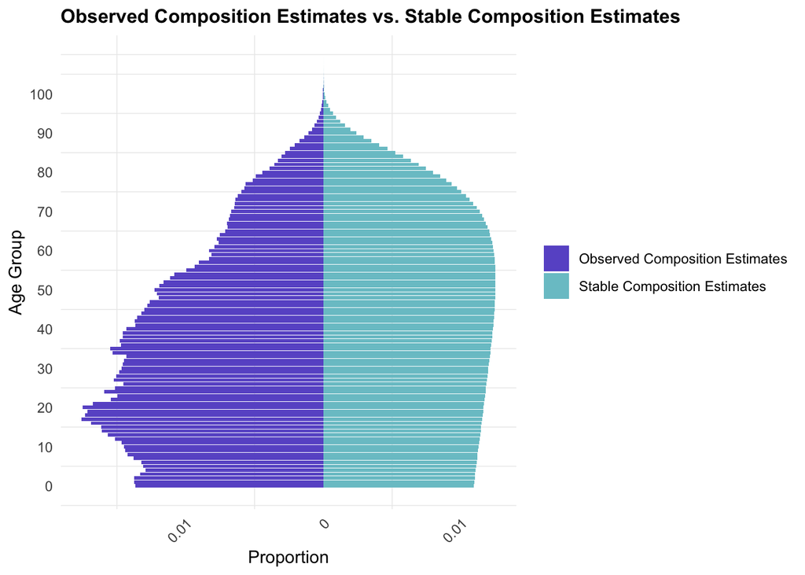

```r
# repeat pre-processing for pop pyramid as in problem #3:
stable_data <- stable_age_composition %>%
  select(Age, Pop_plot = nCx_stable) %>%
  mutate(type = "Stable Composition Estimates")

observed_data <- stable_age_composition %>%
  select(Age, Pop_plot = nCx_observed) %>%
  mutate(Pop_plot = -Pop_plot) %>%
  mutate(type = "Observed Composition Estimates")

sac_plot_data = bind_rows(stable_data, observed_data)

ggplot(sac_plot_data, aes(x = Age, y = Pop_plot, fill = as.factor(type))) +
    geom_bar(stat = "identity", position = "identity") +
    scale_y_continuous(
      labels = abs) +
    scale_x_continuous(
      breaks = seq(0, max(sac_plot_data$Age), by = 10)
    ) +
    coord_flip() +
    theme_minimal() +
    theme(
      axis.text.x = element_text(angle = 45, hjust = 1),
      plot.title = element_text(size = 12, face = "bold"),
      legend.title = element_blank(),
      panel.grid.major = element_blank()) +
    labs(
      x = "Age Group",
      y = "Proportion",
      fill = "type",
      title = paste("Observed Composition Estimates vs. Stable Composition Estimates")
    ) +
    scale_fill_manual(values = setNames(c("slateblue", "cadetblue3"), c("Observed Composition Estimates", "Stable Composition Estimates")))
```

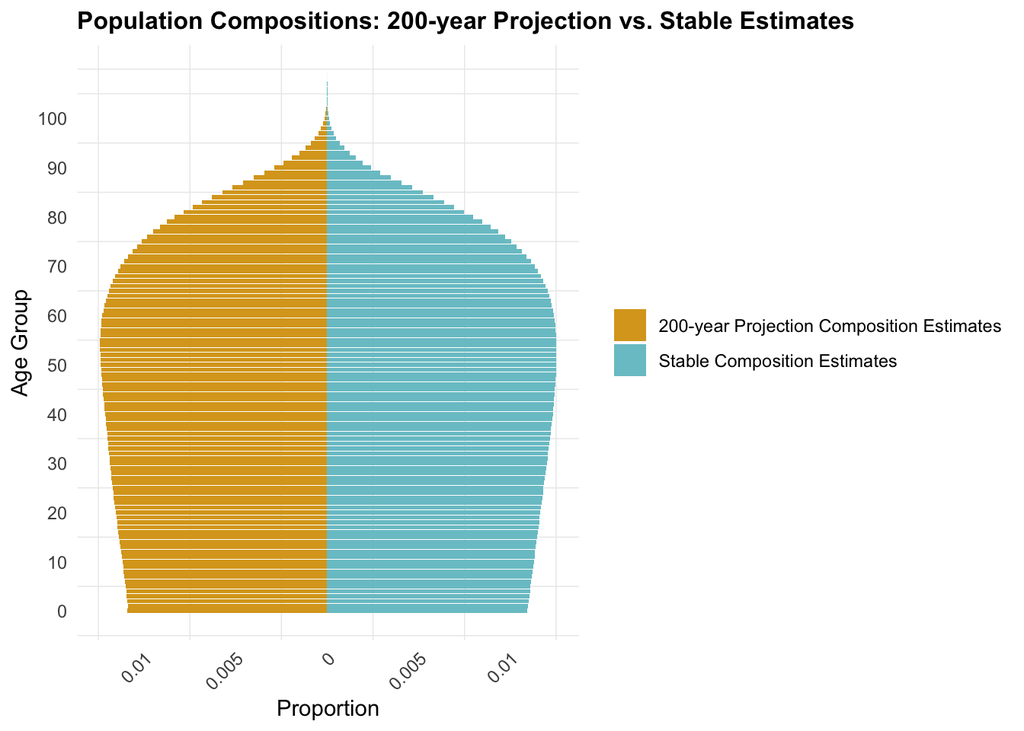

```r
# repeat pre-processing for pop pyramid as in problem #3:
projected_200_data <- ireland_population_projections %>%
  mutate(Pop_plot = -Projection_200_years / sum(Projection_200_years)) %>%
  select(Age, Pop_plot) %>%
  mutate(type = "200-year Projection Composition Estimates") %>%
  mutate(Age = as.numeric(Age))

stable_data <- stable_data %>%
  mutate(Age = as.numeric(Age))

projection_sac_plot_data = bind_rows(projected_200_data, stable_data)

ggplot(projection_sac_plot_data, aes(x = Age, y = Pop_plot, fill = as.factor(type))) +
    geom_bar(stat = "identity", position = "identity") +
    scale_y_continuous(
      labels = abs) +
    scale_x_continuous(
      breaks = seq(0, max(projection_sac_plot_data$Age), by = 10)
    ) +
    coord_flip() +
    theme_minimal() +
    theme(
      axis.text.x = element_text(angle = 45, hjust = 1),
      plot.title = element_text(size = 12, face = "bold"),
      legend.title = element_blank(),
      panel.grid.major = element_blank()) +
    labs(
      x = "Age Group",
      y = "Proportion",
      fill = "type",
      title = paste("Population Compositions: 200-year Projection vs. Stable Estimates")
    ) +
    scale_fill_manual(values = setNames(c("goldenrod", "cadetblue3"), c("200-year Projection Composition Estimates", "Stable Composition Estimates")))
```

These values are incredibly similar, let’s plot just how similar they are to see what the trend looks like:

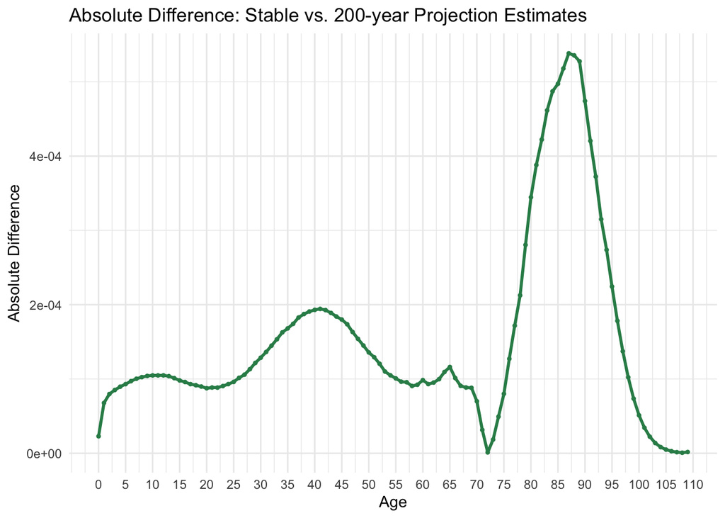

```r
abs_diff_data = data.frame(
  Age = projection_sac_plot_data$Age[1:110],
  abs_diff = abs(abs(projection_sac_plot_data$Pop_plot[1:110]) - abs(stable_data$Pop_plot[1:110]))
)

ggplot(abs_diff_data, aes(x = as.numeric(Age), y = abs_diff)) +
  geom_line(color = "seagreen", linewidth = 1) +
  geom_point(color = "seagreen", size = .85) +
  labs(
    title = "Absolute Difference: Stable vs. 200-year Projection Estimates",
    x = "Age",
    y = "Absolute Difference"
  ) +
  theme_minimal() +
  scale_x_continuous(breaks = seq(0, 110, by = 5))
```

# Problem 4: Impact of Demographic Change – 20 points

Now, let’s look at how demographic changes might impact our stable equivalent population derived in Problem 3.

## (a) 5 points

Calculate the mean age of the stable equivalent population, $A_P$, for the population in Problem 3. **Note:** On pg. 156 of , the following formula is provided:
$$A_P = \dfrac{ \int_{0}^{\omega}
ac(a)da}{\int_0^{\omega} c(a)da}$$

The discrete analogue of this formula is
$$A_P = \dfrac{\sum_{a = 0,n}^{\omega} (a+n/2)
\times {_nC_a}}{\sum_{a = 0,n}^{\omega} {_nC_a}}$$

```r
A_p = (sum( (stable_age_composition$Age + n/2) * stable_age_composition$nCx_stable) ) / sum(stable_age_composition$nCx_stable)

cat("The mean age of the stable equivalent population is", round(A_p, 2), "years old.")
```

```
## The mean age of the stable equivalent population is 42.85 years old.
```

## (b) 5 points

What is the $NRR$ for your stable equivalent population? If fertility returned to replacement level in your stable equivalent population, what would happen to the ${_nC_a}$ for ages $a$ below the mean age of the population, $A_P$? What would happen to the ${_nC_a}$ for ages $a$ above the mean age of the population, $A_P$?

$NRR = e^{rT}$, where $r = \text{lotka's r}$ and $T = 28$. Therefore, the stable equivalent population NRR is:

```r
# 0.007271872
NRR_stable = exp(-0.003374234*t)

cat("The stable equivalent population NRR is:", round(NRR_stable, 4), "whereas the observed population NRR is:", round(NRR, 4))
```

```
## The stable equivalent population NRR is: 0.9098 whereas the observed population NRR is: 0.9084
```

In the long-term there would also be a decrease in the number of people below the mean age of the population, because more people would subject to the force of fertility and mortality in those age groups as time passes, and the youngest “baby boom” would age up, causing an aging in the population.

## (c) 10 points

Using the current $NRR$ from (b), you can calculate a scaling factor of $1/NRR$ to apply to each ${_nF_a^{f}}$ to create $m^{\star}(a)$ values that yield a $NRR$ of 1.

Then, calculate the scaling factor, the new NRR, the new $r$, and the new $m^{\star}(a)$ based on the underlying age-specific fertility rates used in the column `Female_ASFR` from the dataframe “ireland_data_2000F”.

**This answer uses concepts from the Lecture 14 demo provided by Jess Godwin to compute the stable equivalent population scaling factor, new NRR, new fertility rates, and new r:**

We know that:

1. $$NRR = \int_{\alpha}^\beta p(a)
   \times m(a) da$$
   and
2. $$1 = \int_{\alpha}^\beta e^{-ra}
   \times p(a) \times m(a) da$$

We want to calculate the new NRR scaling factor, the new NRR, and new Lotka’s r.

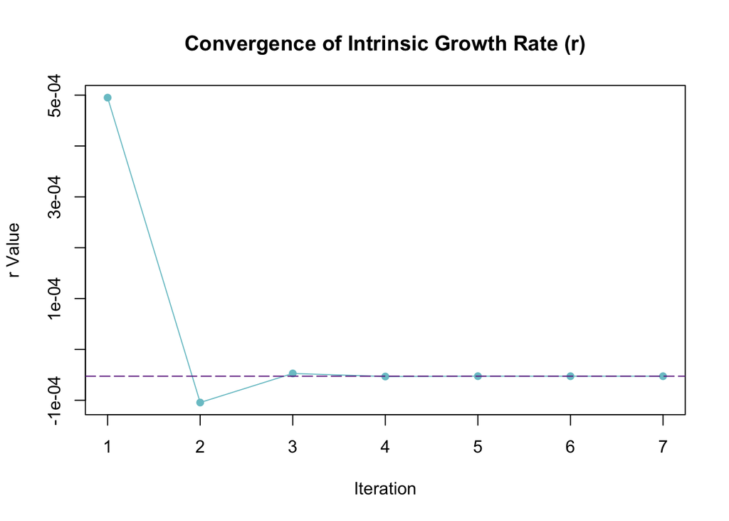

```r
tolerance = 1e-6
max_iter = 10
NRR_scale = 1 / NRR_stable

# Apply the scaling factor to the fertility rates (make m-stars)
ireland_data_2000F$m_star = ireland_data_2000F$Female_ASFR * NRR_scale

# Recalculate the intrinsic growth rate r using the new fertility rates
# make an empty vector for the possible lotka's r values
r_values = numeric(max_iter)

for (i in 1:max_iter) {
  # Compute y(r_n) using the adjusted fertility rates
  # take a guess, I used the old r_n from earlier in the code
  y_rn = sum(exp(-r_n * (ireland_data_2000F$Age + 1/2)) *
                (ireland_data_2000F$Female_Lx / ireland_data_2000F$Female_lx[1]) *
                ireland_data_2000F$m_star)

  # Compute next estimate r_{n+1}
  r_next = r_n + (y_rn - 1) / 28
  r_values[i] = r_next

  # Check for convergence
  if (abs(y_rn - 1) < tolerance) {
    r_values = r_values[1:i]
    break
  }
  r_n = r_next
}

# If it reached max iterations without converging
if (abs(y_rn - 1) >= tolerance) {
  cat("Failed to converge after", max_iter, "iterations.\n")
}

ireland_data_2000F$m_star_new = ireland_data_2000F$m_star

# Sanity check: NRR for the adjusted fertility rates (using m-stars) should be close to 1
NRR_new = sum(ireland_data_2000F$Female_Lx / ireland_data_2000F$Female_lx[1] * ireland_data_2000F$m_star)


plot(1:length(r_values), r_values, type = "o", pch = 16, col = "cadetblue3",
     xlab = "Iteration", ylab = "r Value",
     main = "Convergence of Intrinsic Growth Rate (r)")
abline(h = r_values[length(r_values)], col = "darkorchid4", lty = 5)
```

```r
cat("Reciprocal of the stable equivalent population NRR:", round(NRR_scale, 4), "\n")
```

```
## Reciprocal of the stable equivalent population NRR: 1.0991
```

```r
cat("Re-calculated Lotka's r:", format(round(r_values[length(r_values)], 6), scientific= FALSE), "\n")
```

```
## Re-calculated Lotka's r: -0.000053
```

```r
cat("Re-calculated NRR based on the m-star fertility rates:", round(NRR_new, 4), "\n")
```

```
## Re-calculated NRR based on the m-star fertility rates: 0.9984
```